# Motor Trend - Regression

Joost van Brakel

October 20, 2015

# Executive summary

We at Motor Trend are looking to better understand the relationship between miles per gallon and a number design and performance aspects. Our initial focus was on transmitions, however this results provided no viable forecasting models, due to the binary nature of the transmition (Auto / Manual). By researching the other aspects we were able to determinedthat the best way to forecast MPG was by looking at the weight and the horsepower of the car.

# Process

For this analysis we used R and a number of key libraries, namely : xtable, GGally, car and ggplot2

## data

The data utilized was extracted from the 1974 Motor Trend US magazine, and comprises fuel consumption (MPG) and 10 aspects of automobile design and performance for 32 automobiles (1973–74 models). The data utilize is part of R and is called ‘mtcars’. It was pulled into the dataset variable for analysis and no transformation were performed for this analysis. A legend of the fields is included in appendix 1.

Our first step was to examine the the impact of the transmition type on Miles per Gallon.

Key descriptive stats

|  | id | mean | Variance | Length | Standard Dev |
| --- | --- | --- | --- | --- | --- |
| 1 | Manual | 24.39 | 38.03 | 13.00 | 6.17 |
| 2 | Automatic | 17.15 | 14.70 | 19.00 | 3.83 |

Results comparing transmitions (Two side T test)

|  | test | df | t | p | p outcome | t outcome | 2.5% | 97.5% |
| --- | --- | --- | --- | --- | --- | --- | --- | --- |
| 1 | Automatic vs Manual | 18.33 | -3.77 | 0.00 | pass | pass | -2.10 | 2.10 |

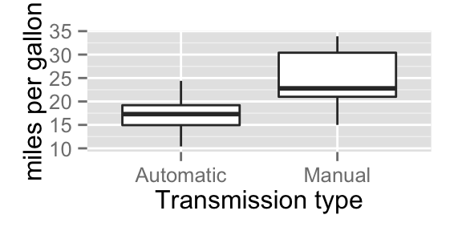

As the chart and the statistics above highlight, there is a significant difference between the two transmition types with the with P values below 0.05 and the t test shows that the t value is outside confidence interval.

# How different are the MPG stats

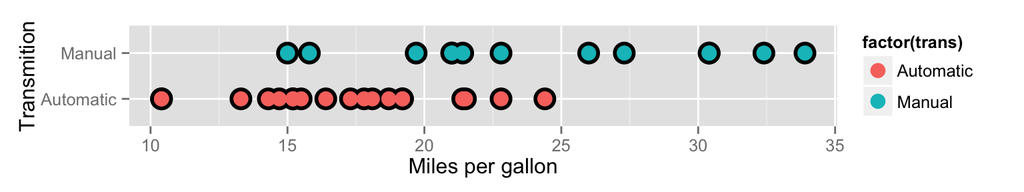

To better forecast MPG, we have looked at the broader set of design and performance options. In appendix 2 we include a chart that compares all the different factors. Looking at the correlation with MPG and the factors, we noticed that cylenders, displacements, horsepower and weight have a high correlation(0.75+). We could build a model with all those factors, but that could create the risk of over fitting. To minimize the number of factors we looked at eliminiating factors that had a high correlation between each other. The chart in appendix 3 maps out the relationship between the key factors. It shows that the majority of factors have a high degree of correlation, but weight and horsepower have the lowest correlation.

Results comparing models

|  | model | R Square | Adj, R Square |
| --- | --- | --- | --- |
| 1 | Model 1 | 0.7183 | 0.7090 |
| 2 | Model 2 | 0.8268 | 0.8148 |
| 3 | Model 3 | 0.8268 | 0.8083 |

# Final results

Comparing the results both model 2 and 3 have acceptable R Squared, and on an R Squared basis both are simular for model 2 and 3, however model 2 has fewer inputs and this results in an improved adjusted r squared. It also has a lower VIF, which we have included in the appendix. Therefore model 2 is the prefered model. We also examined the residuals, which showed no particular patern.

So how to use this model :

Model 2

|  | Estimate | Std. Error | t value | Pr(>\|t\|) |
| --- | --- | --- | --- | --- |
| (Intercept) | 37.2273 | 1.5988 | 23.2847 | 0.0000 |
| wt | -3.8778 | 0.6327 | -6.1287 | 0.0000 |
| hp | -0.0318 | 0.0090 | -3.5187 | 0.0015 |

To forecast the MPG usage of the car you will have to fill in the following formula :  
MPG usage = 37.2 - 3. 88 x Weight - 0.03 x Horsepower

# Appendix

## 1. Legend

Here is the Legend for the fields being utilized in this analysis

- mpg, Miles/(US) gallon
- cyl, Number of cylinders
- disp, Displacement (cu.in.)
- hp, Gross horsepower
- drat, Rear axle ratio
- wt, Weight (lb/1000)
- qsec, 1/4 mile time
- vs, V/S
- am, Transmission (0 = automatic, 1 = manual)
- gear, Number of forward gears
- carb, Number of carburetors

## 2. Correlation Chart

The focus is on the first column as that highlights the relationship of the design/perfomance choices and MPG.

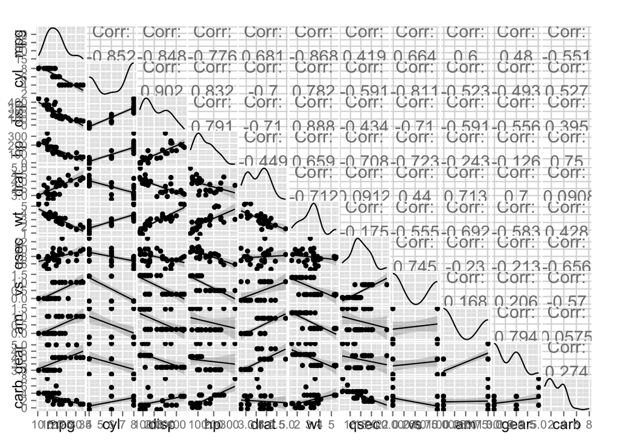

## 3. Correlation Chart for specific factors

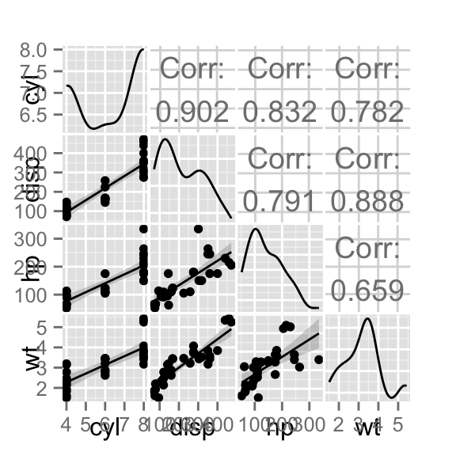

## 4. Details on Model 1 and 3 [1] “Model 1”

Model 1

|  | Estimate | Std. Error | t value | Pr(>\|t\|) |
| --- | --- | --- | --- | --- |
| (Intercept) | 29.5999 | 1.2297 | 24.0704 | 0.0000 |
| disp | -0.0412 | 0.0047 | -8.7472 | 0.0000 |

[1] “Model 3”

Model 3

|  | Estimate | Std. Error | t value | Pr(>\|t\|) |
| --- | --- | --- | --- | --- |
| (Intercept) | 37.1055 | 2.1108 | 17.5788 | 0.0000 |
| wt | -3.8009 | 1.0662 | -3.5649 | 0.0013 |
| disp | -0.0009 | 0.0103 | -0.0905 | 0.9285 |
| hp | -0.0312 | 0.0114 | -2.7245 | 0.0110 |

## 5. VIF Details on Model 2 and 3

Model 2 VIF

|  | vif(lm(mpg ~ wt + hp, data = dataset)) |
| --- | --- |
| wt | 1.7666 |
| hp | 1.7666 |

Model 3 VIF

|  | vif(lm(mpg ~ wt + disp + hp, data = dataset)) |
| --- | --- |
| wt | 4.8446 |
| disp | 7.3245 |
| hp | 2.7366 |

## 6. Details on Model 2 (Residual)

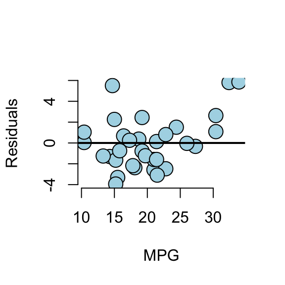

No clear patern is visible, which is good